# Assignment 9: Auction

Kohei Kawaguchi

2019/1/29

## Simulate data

We simulate bid data from a second- and first-price sealed bid auctions.

1. Set the constants and parameters as follows:

```r
# set seed
set.seed(1)
# number of auctions
T <- 100
# parameter of value distribution
alpha <- 2
beta <- 2
# prameters of number of potential bidders
lambda <- 10
```

2. Draw a vector of valuations and reservation prices.

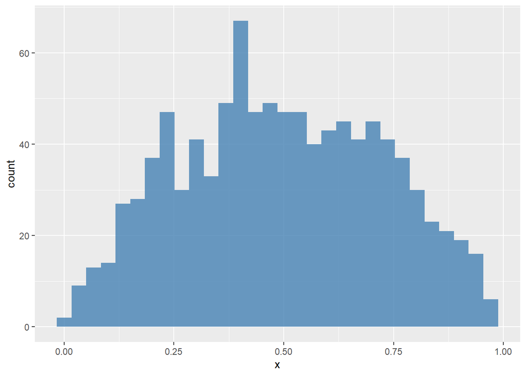

```r
# number of bidders
N <- rpois(T, lambda)
N <- ifelse(N == 1, 2, N)
# draw valuations
valuation <-
  foreach (tt = 1:T, .combine = "rbind") %do% {
    n_t <- N[tt]
    header <- expand.grid(t = tt, i = 1:n_t)
    return(header)
  }
valuation <- valuation %>%
  tibble::as_tibble() %>%
  dplyr::mutate(x = rbeta(length(i), alpha, beta))
ggplot(valuation, aes(x = x)) + geom_histogram(fill = "steelblue", alpha = 0.8)
```

```r
# draw reserve prices
reserve <- 0.2
reserve <- tibble::tibble(t = 1:T, r = reserve)
```

3. Write a function `compute_winning_bids_second(valuation, reserve)` that returns a winning bid from each second-price auction. It returns nothing for an auction in which no bid was above the reserve price. In the output, `t` refers to the auction index, `m` to the number of actual bidders, `r` to the reserve price, and `w` to the winning bid.

```r
# compute winning bids from second-price auction
df_second_w <-
  compute_winning_bids_second(valuation, reserve)
df_second_w
```

```
## # A tibble: 100 × 5
##        t     n     m     r     w
##    <int> <int> <int> <dbl> <dbl>
##  1     1     8     8   0.2 0.637
##  2     2    10    10   0.2 0.647
##  3     3     7     5   0.2 0.484
##  4     4    11     8   0.2 0.804
##  5     5    14    12   0.2 0.920
##  6     6    12    11   0.2 0.942
##  7     7    11     9   0.2 0.810
##  8     8     9     9   0.2 0.724
##  9     9    14    14   0.2 0.880
## 10    10    11     9   0.2 0.677
## # … with 90 more rows
## # ℹ Use `print(n = ...)` to see more rows
```

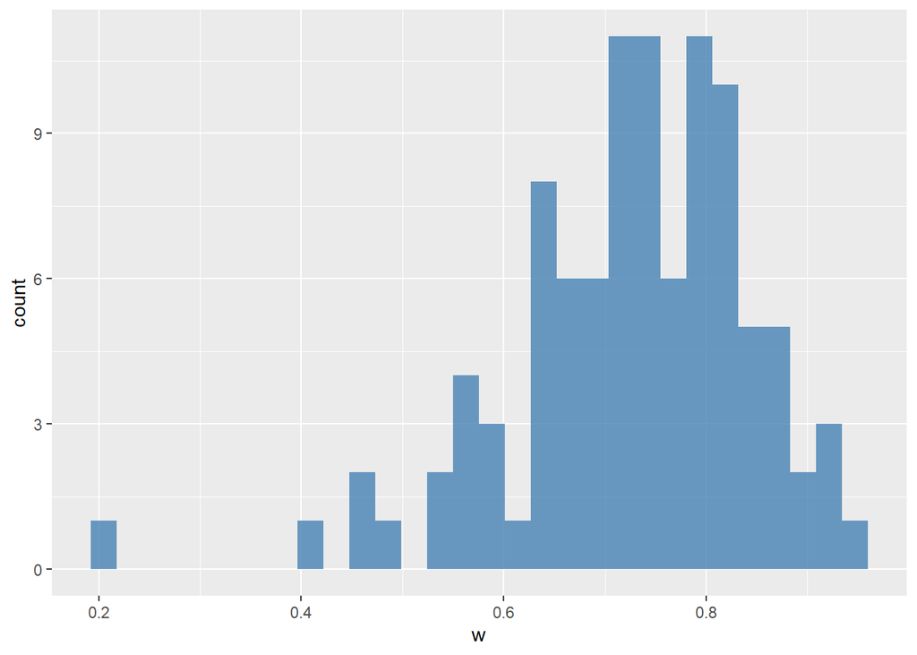

```r
ggplot(df_second_w, aes(x = w)) + geom_histogram(fill = "steelblue", alpha = 0.8)
```

Next, we simulate bid data from first-price sealed bid auctions. The setting is the same as the second-price auctions expect for the auction rule. An equilibrium bidding strategy is to participate and bid:
$$\beta(x) = x - \frac{\int_{r_t}^x F_X(t)^{N - 1}}{F_X(x)^{N - 1}},$$
if $x \ge r$ and not to participate otherwise.

4. Write a function `bid_first(x, r, alpha, beta, n)` that returns the equilibrium bid. To integrate a function, use `integrate` function in R. It returns 0 if $x < r$.

```r
# compute bid from first-price auction
n <- N[1]
m <- N[1]
x <- valuation[1, "x"] %>% as.numeric(); x
```

```
## [1] 0.3902289
```

```r
r <- reserve[1, "r"] %>% as.numeric(); r
```

```
## [1] 0.2
```

```r
b <- bid_first(x, r, alpha, beta, n); b
```

```
## [1] 0.3596662
```

```r
x <- r/2; x
```

```
## [1] 0.1
```

```r
b <- bid_first(x, r, alpha, beta, n); b
```

```
## [1] 0
```

```r
b <- bid_first(1, r, alpha, beta, n); b
```

```
## [1] 0.7978258
```

5. Write a function `compute_bids_first(valuation, reserve, alpha, beta)` that returns bids from each first-price auctions. It returns bids below the reserve price.

```r
# compute bid data from first-price auctions
df_first <- compute_bids_first(valuation, reserve, alpha, beta)
df_first
```

```
## # A tibble: 994 × 7
##        t     i     x     r     n     m     b
##    <int> <int> <dbl> <dbl> <int> <int> <dbl>
##  1     1     1 0.390   0.2     8     8 0.360
##  2     1     2 0.410   0.2     8     8 0.378
##  3     1     3 0.422   0.2     8     8 0.388
##  4     1     4 0.637   0.2     8     8 0.577
##  5     1     5 0.450   0.2     8     8 0.413
##  6     1     6 0.359   0.2     8     8 0.332
##  7     1     7 0.837   0.2     8     8 0.731
##  8     1     8 0.440   0.2     8     8 0.404
##  9     2     1 0.449   0.2    10    10 0.420
## 10     2     2 0.472   0.2    10    10 0.441
## # … with 984 more rows
## # ℹ Use `print(n = ...)` to see more rows
```

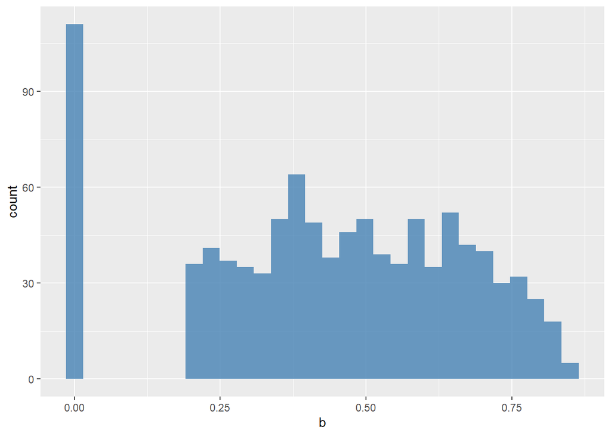

```r
ggplot(df_first, aes(x = b)) + geom_histogram(fill = "steelblue", alpha = 0.8)
```

6. Write a function `compute_winning_bids_first(valuation, reserve, alpha, beta)` that returns only the winning bids from each first-price auction. It will call `compute_bids_first` inside the function. It does not return anything when no bidder bids above the reserve price.

```r
# compute winning bids from first-price auctions
df_first_w <-
  compute_winning_bids_first(valuation, reserve, alpha, beta)
df_first_w
```

```
## # A tibble: 100 × 5
##        t     n     m     r     w
##    <int> <int> <int> <dbl> <dbl>
##  1     1     8     8   0.2 0.731
##  2     2    10    10   0.2 0.638
##  3     3     7     5   0.2 0.525
##  4     4    11     8   0.2 0.818
##  5     5    14    12   0.2 0.842
##  6     6    12    11   0.2 0.833
##  7     7    11     9   0.2 0.772
##  8     8     9     9   0.2 0.753
##  9     9    14    14   0.2 0.849
## 10    10    11     9   0.2 0.803
## # … with 90 more rows
## # ℹ Use `print(n = ...)` to see more rows
```

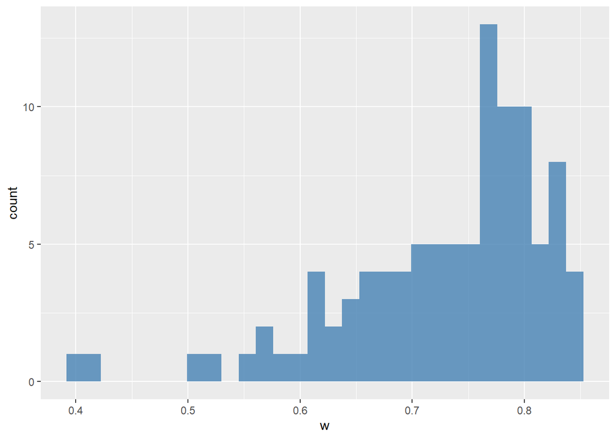

```r
ggplot(df_first_w, aes(x = w)) + geom_histogram(fill = "steelblue", alpha = 0.8)
```

## Estimate the parameters

We first estimate the parameters from the winning bids data of second-price auctions. We estimate the parameters by maximizing a log-likelihood.

$$l(\alpha, \beta) := \frac{1}{T} \sum_{t = 1}^T \ln\frac{h_t(w_t)^{1\{m_t
> 1\}} \mathbb{P}\{m_t = 1\}^{1\{m_t = 1\}}}{1 - \mathbb{P}\{m_t =
0\}},$$
where:
$$\mathbb{P}\{m_t = 0\} := F_X(r_t)^{n_t},$$
$$\mathbb{P}\{m_t = 1\} := n_t F_X(r_t; \alpha, \beta)^{n_t - 1} [1 -
F_X(r_t; \alpha, \beta)].$$

$$h_t(w_t) := n_t (n_t - 1) F_X(w_t; \alpha, \beta)^{n_t - 2} [1 -
F_X(w_t; \alpha, \beta)] f_X(w_t; \alpha, \beta).$$

1. Write a function `compute_p_second_w(w, r, m, n, alpha, beta)` that computes $\mathbb{P}\{m_t = 1\}$ if $m_t = 1$ and $h_t(w_t)$ if $m_t > 1$.

```r
# compute probability density for winning bids from a second-price auction
w <- df_second_w[1, ]$w
r <- df_second_w[1, ]$r
m <- df_second_w[1, ]$m
n <- df_second_w[1, ]$n
compute_p_second_w(w, r, m, n, alpha, beta)
```

```
## [1] 2.752949
```

2. Write a function `compute_m0(r, n, alpha, beta)` that computes $\mathbb{P}\{m_t = 0\}$.

```r
# compute non-participation probability
compute_m0(r, n, alpha, beta)
```

```
## [1] 1.368569e-08
```

2. Write a function `compute_loglikelihood_second_price_w(theta, df_second_w)` that computes the log-likelihood for a second-price auction winning bid data.

```r
# compute log-likelihood for winning bids from second-price auctions
theta <- c(alpha, beta)
compute_loglikelihood_second_price_w(theta, df_second_w)
```

```
## [1] 0.9849261
```

3. Compare the value of objective function around the true parameters.

```r
# label
label <- c("\\alpha", "\\beta")
label <- paste("$", label, "$", sep = "")
# compute the graph
graph <- foreach (i = 1:length(theta)) %do% {
  theta_i <- theta[i]
  theta_i_list <- theta_i * seq(0.8, 1.2, by = 0.05)
  objective_i <-
    foreach (j = 1:length(theta_i_list),
             .packages = c(
               "EmpiricalIO",
               "foreach",
               "magrittr"
               ),
             .combine = "rbind") %dopar% {
               theta_ij <- theta_i_list[j]
               theta_j <- theta
               theta_j[i] <- theta_ij
               objective_ij <-
                 compute_loglikelihood_second_price_w(
                   theta_j, df_second_w)
               return(objective_ij)
             }
  df_graph <- data.frame(x = as.numeric(theta_i_list),
                         y = as.numeric(objective_i))
  g <- ggplot(data = df_graph, aes(x = x, y = y)) +
    geom_point() +
    geom_vline(xintercept = theta_i, linetype = "dotted") +
    ylab("objective function") + xlab(TeX(label[i]))
  return(g)
}
save(graph, file = "data/A9_second_parametric_graph.RData")
```

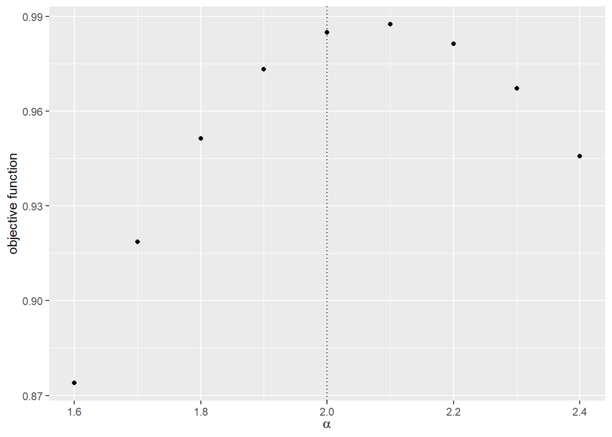

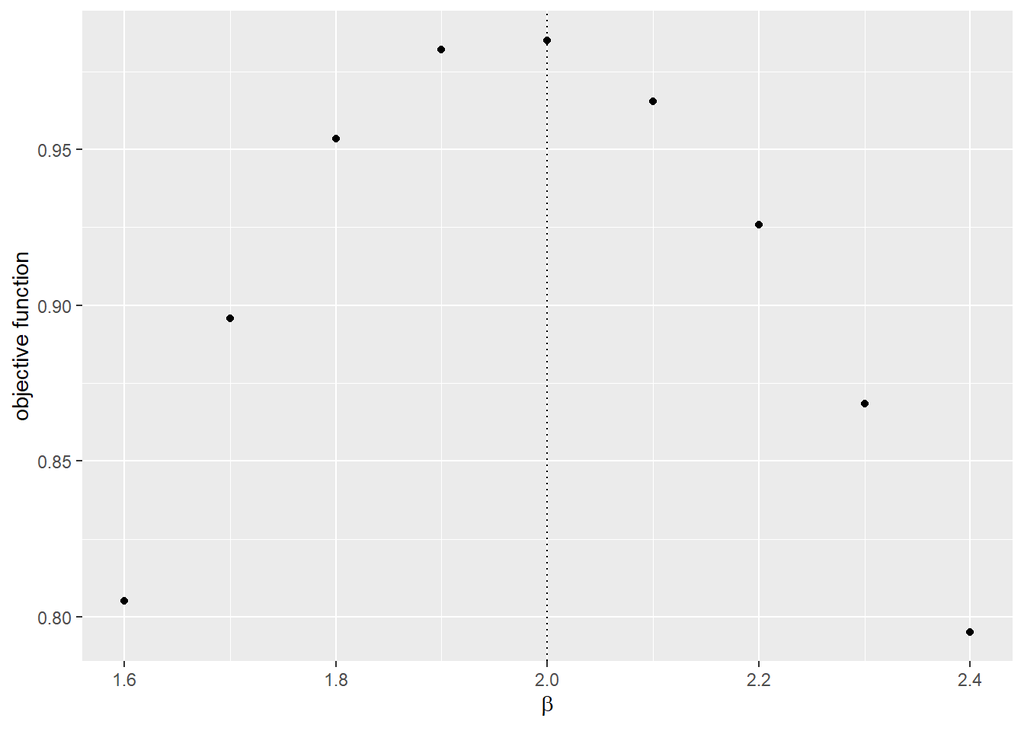

```r
load(file = "data/A9_second_parametric_graph.RData")
graph
```

4. Estimate the parameters by maximizing the log-likelihood.

```r
result_second_parametric <-
  optim(
    par = theta,
    fn = compute_loglikelihood_second_price_w,
    df_second_w = df_second_w,
    method = "L-BFGS-B",
    control = list(fnscale = -1)
  )
save(result_second_parametric, file = "data/A9_result_second_parametric.RData")
```

```r
load(file = "data/A9_result_second_parametric.RData")
result_second_parametric
```

```
## $par
## [1] 2.199238 2.078327
##
## $value
## [1] 0.9883372
##
## $counts
## function gradient
##       11       11
##
## $convergence
## [1] 0
##
## $message
## [1] "CONVERGENCE: REL_REDUCTION_OF_F <= FACTR*EPSMCH"
```

```r
comparison <-
  data.frame(
    true = theta,
    estimate = result_second_parametric$par
  )
comparison
```

```
##   true estimate
## 1    2 2.199238
## 2    2 2.078327
```

Next, we estimate the parameters from the winning bids data from first-price auctions. We estimate the parameters by maximizing a log-likelihood.

5. Write a function `inverse_bid_equation(x, b, r, alpha, beta, n)` that returns $\beta(x) - b$ for a bid $b$. Write a function `inverse_bid_first(b, r, alpha, beta, n)` that is an inverse function `bid_first` with respect to the signal, that is,
   $$\eta(b) := \beta^{-1}(b).$$

```r
r <- df_first_w[1, "r"] %>%
  as.numeric()
n <- df_first_w[1, "n"] %>%
  as.integer()
b <- 0.5 * r + 0.5
x <- 0.5
# compute invecrse bid equation
inverse_bid_equation(x, b, r, alpha, beta, n)
```

```
## [1] -0.1421105
```

```r
# compute inverse bid
inverse_bid_first(b, r, alpha, beta, n)
```

```
## [1] 0.6653238
```

The log-likelihood conditional on $m_t \ge 1$ is:
$$l(\alpha, \beta) := \frac{1}{T}\sum_{t = 1}^T \log \frac{h_t(w_t)}{1 -
F_X(r_t)^{n_t}},$$
where the probability density of having $w_t$ is:
$$\begin{split}
h_t(w_t) &= n_t F_X[\eta_t(w_t)]^{n_t - 1} f_X[\eta_t(w_t)]
\eta_t'(w_t)\\
&= \frac{n_t F_X[\eta_t(w_t)]^{n_t}}{(n_t - 1)[\eta_t(w_t) - w_t]},
\end{split}$$
where the second equation is from the first-order condition.

6. Write a function `compute_p_first_w(w, r, alpha, beta, n)` that returns $h_t(w)$. Remark that the equilibrium bid at specific parameters is `bid_first(1, r, alpha, beta, n)`. If the observed wining bid `w` is above the upper limit, the function will issue an error. Therefore, inside the function `compute_p_first_w(w, r, alpha, beta, n)`, check if `w` is above `bid_first(1, r, alpha, beta, n)` and if so return $10^{-6}$.

```r
# compute probability density for a winning bid from a first-price auction
w <- 0.5
compute_p_first_w(w, r, alpha, beta, n)
```

```
## [1] 0.2720049
```

```r
upper <- bid_first(1, r, alpha, beta, n)
compute_p_first_w(upper + 1, r, alpha, beta, n)
```

```
## [1] 1e-06
```

7. Write a function `compute_loglikelihood_first_price_w(theta, df_first_w)` that computes the log-likelihood for a first-price auction winning bid data.

```r
# compute log-likelihood for winning bids for first-price auctions
compute_loglikelihood_first_price_w(theta, df_first_w)
```

```
## [1] 1.597414
```

8. Compare the value of the objective function around the true parameters.

```r
theta <- c(alpha, beta)
# label
label <- c("\\alpha", "\\beta")
label <- paste("$", label, "$", sep = "")
# compute the graph
graph <- foreach (i = 1:length(theta)) %do% {
  theta_i <- theta[i]
  theta_i_list <- theta_i * seq(0.8, 1.2, by = 0.05)
  objective_i <-
    foreach (j = 1:length(theta_i_list),
             .packages = c(
               "EmpiricalIO",
               "foreach",
               "magrittr"
               ),
             .combine = "rbind") %dopar% {
               theta_ij <- theta_i_list[j]
               theta_j <- theta
               theta_j[i] <- theta_ij
               objective_ij <-
                 compute_loglikelihood_first_price_w(
                   theta_j, df_first_w)
               return(objective_ij)
             }
  df_graph <- data.frame(x = as.numeric(theta_i_list),
                         y = as.numeric(objective_i))
  g <- ggplot(data = df_graph, aes(x = x, y = y)) +
    geom_point() +
    geom_vline(xintercept = theta_i, linetype = "dotted") +
    ylab("objective function") + xlab(TeX(label[i]))
  return(g)
}
save(graph, file = "data/A9_first_parametric_graph.RData")
```

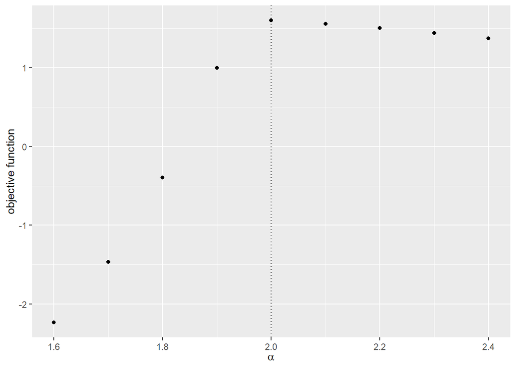

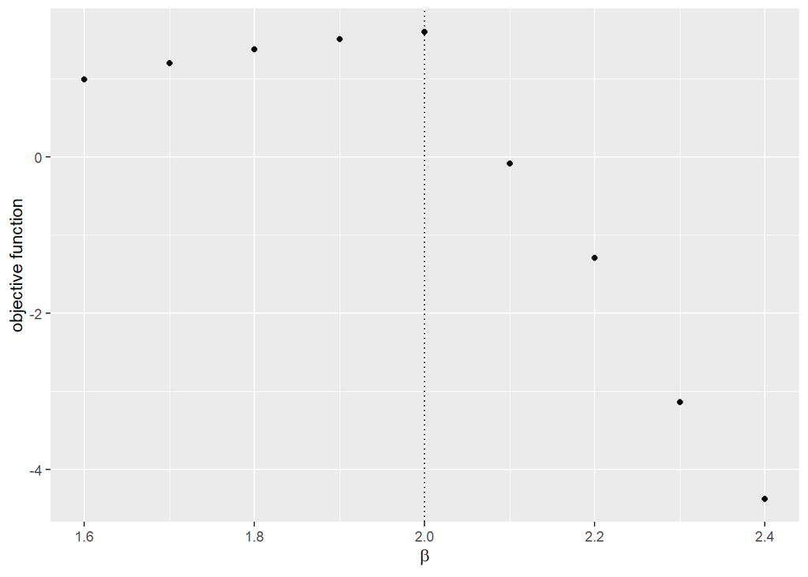

```r
load(file = "data/A9_first_parametric_graph.RData")
graph
```

```r
result_first_parametric <-
  optim(
    par = theta,
    fn = compute_loglikelihood_first_price_w,
    df_first_w = df_first_w,
    method = "Nelder-Mead",
    control = list(fnscale = -1)
  )
save(result_first_parametric, file = "data/A9_result_first_parametric.RData")
```

```r
load(file = "data/A9_result_first_parametric.RData")
result_first_parametric
```

```
## $par
## [1] 1.977676 2.004715
##
## $value
## [1] 1.607161
##
## $counts
## function gradient
##       91       NA
##
## $convergence
## [1] 0
##
## $message
## NULL
```

```r
comparison <-
  data.frame(
    true = theta,
    estimate = result_first_parametric$par
  )
comparison
```

```
##   true estimate
## 1    2 1.977676
## 2    2 2.004715
```

Finally, we non-parametrically estimate the distribution of the valuation using bid data from first-price auctions `df_first`.

10. Write a function `F_b(b)` that returns an empirical cumulative distribution at `b`. This can be obtained by using a function `ecdf`. Also, write a function `f_b(b)` that returns an empirical probability density at `b`. This can be obtained by combining functions `approxfun` and `density`.

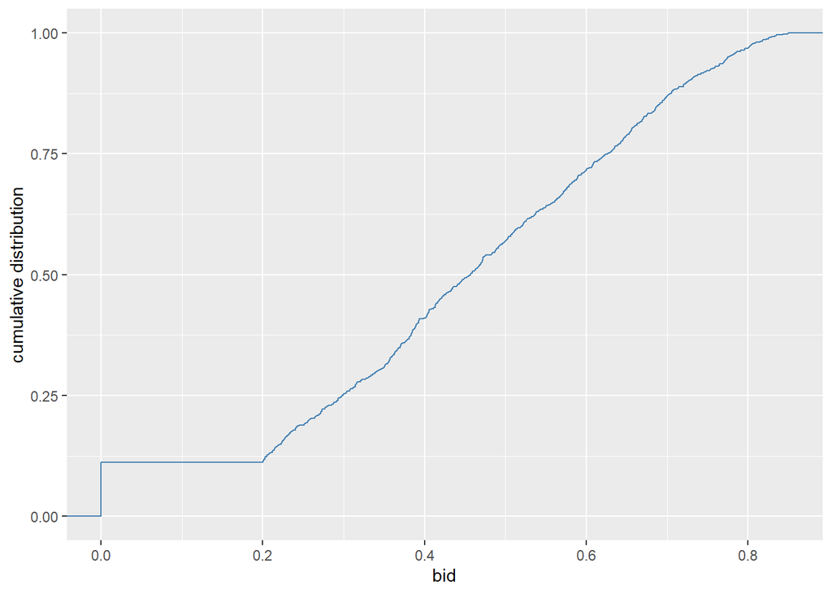

```r
# cumulative distribution
ggplot(df_first, aes(x = b)) + stat_ecdf(color = "steelblue") +
  xlab("bid") + ylab("cumulative distribution")
```

```r
F_b <- ecdf(df_first$b)
F_b(0.4)
```

```
## [1] 0.4104628
```

```r
F_b(0.6)
```

```
## [1] 0.7173038
```

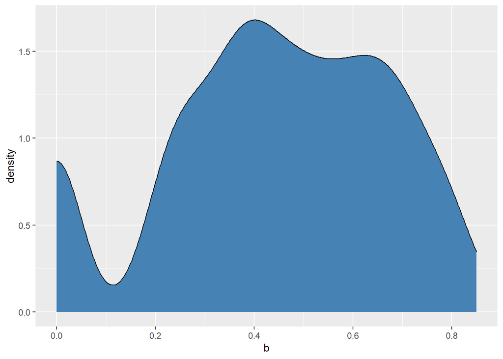

```r
# probability density
ggplot(df_first, aes(x = b)) + geom_density(fill = "steelblue")
```

```r
f_b <- approxfun(density(df_first$b))
f_b(0.4)
```

```
## [1] 1.680124
```

```r
f_b(0.6)
```

```
## [1] 1.469983
```

The equilibrium distribution and density of the highest rival’s bid are:
$$H_b(b) := F_b(b)^{n - 1},$$
$$h_b(b) := (n - 1) f_b(b) F_b(b)^{n - 2}.$$

```r
H_b(0.4, n, F_b)
```

```
## [1] 0.001962983
```

```r
h_b(0.4, n, F_b, f_b)
```

```
## [1] 0.05624476
```

When a bidder bids $b$, the implied valuation of her is:
$$x = b + \frac{H_b(b)}{h_b(b)}.$$

12. Write a function `compute_implied_valuation(b, n, r)` that returns the implied valuation given a bid. Let it return $x = 0$ if $b < r$, because we cannot know the value when the bid is below the reserve price.

```r
r <- df_first[1, "r"]
n <- df_first[1, "n"]
compute_implied_valuation(0.4, n, r, F_b, f_b)
```

```
##           n
## 1 0.4349007
```

13. Obtain the vector of implied valuations from the vector of bids and draw the empirical cumulative distribution. Overlay it with the true empirical cumulative distribution of the valuations.

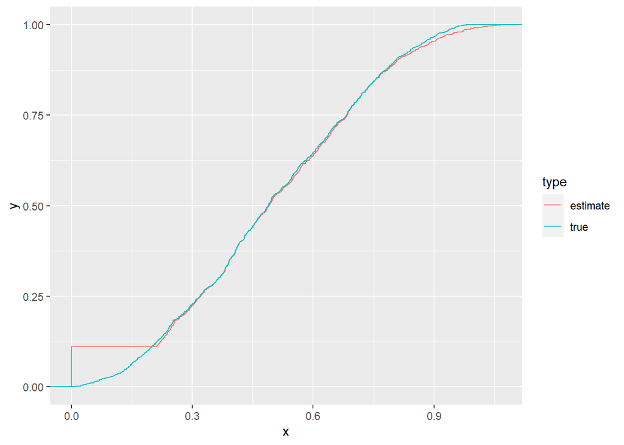

```r
valuation_implied <- df_first %>%
  dplyr::rowwise() %>%
  dplyr::mutate(x = compute_implied_valuation(b, n, r, F_b, f_b)) %>%
  dplyr::ungroup() %>%
  dplyr::select(x) %>%
  dplyr::mutate(type = "estimate")
valuation_true <- valuation %>%
  dplyr::select(x) %>%
  dplyr::mutate(type = "true")
valuation_plot <- rbind(valuation_true, valuation_implied)
ggplot(valuation_plot, aes(x = x, color = type)) + stat_ecdf()
```